# Introduction to Tidyverse

The tidyverse is a collection of packages for doing data science:

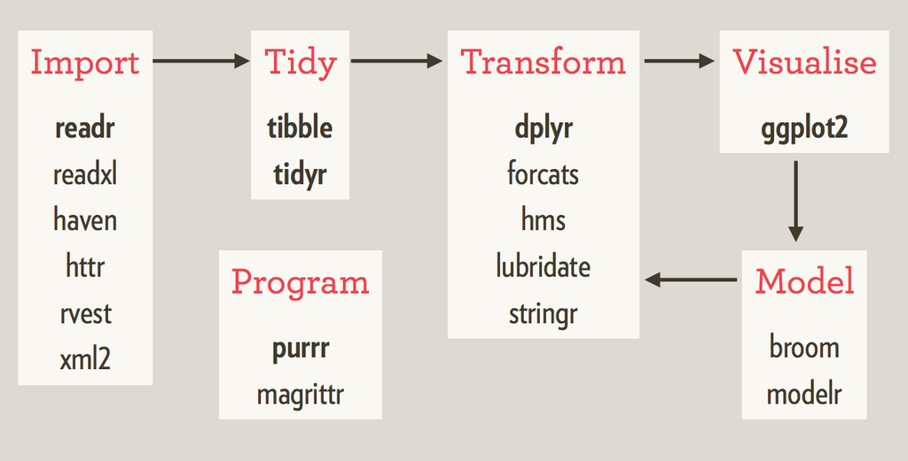

It includes a website: http://tidyverse.org and a book: http://r4ds.had.co.nz

At the heart of the tidyverse is tidy data. Every variable is a column, every row is a case.

## Tidy Data:

First, we can create a toy dataset with untidy data:

```r
#install.packages("tidyverse")
library(tidyverse)

untidy <-
  tribble(
    ~Country, ~`2011`, ~`2012`, ~`2013`,
    'FR', 7000, 6900, 7000,
    'DE', 5800, 6000, 15000,
    'US', 15000, 14000, 13000
)

untidy # this is a tibble, which is a special type of data frame
```

[output not shown]

This data is difficult to work with. We can use `tidyr::gather` to tidy it:

```r
tidy <- untidy %>% # magrittr's pipe operator
  gather(key = "Year", value = "Metric", 2:4)  %>% # tidyr::gather to make wide data tall
  mutate(Year = as.numeric(Year)) # dplyr::mutate to change or add a column
tidy
```

[output not shown]

## ggplot2

Now that the data is tidy we can use other tools in the tidyverse, like `ggplot2`:

```r
# ggplot loves tidy data
# Pro Tip: if you're ever stuck in ggplot2, go back to your data!
ggplot(tidy, aes(x = Year, y = Metric, color = Country)) +
  geom_line()
```

[output not shown]

### dplyr + lubridate (flight delay by day of week)

For a more complete example we’ll use the `nycflights13` dataset to answer the question: “What day of the week has the highest average delay?”

One key component of the tidyverse is `dplyr` which uses verbs to manipulate tidy datasets.

```r
library(nycflights13) # data is in the flights table
library(lubridate) # load the lubridate package for dates

flights %>%
  mutate(dow = lubridate::wday(time_hour, label = TRUE)) %>% # lubridate to get week day from date object
  select(dow, arr_delay) %>%                                 # select relevant columns
  filter(arr_delay > 0) %>%                                  # filter rows on a condition
  group_by(dow) %>%                                          # group by day
  summarise(avg_delay = mean(arr_delay)) %>%                 # and calculate average delay
  ggplot(aes(dow, avg_delay)) +
  geom_bar(stat = "identity") +                              # bar plots in ggplot2
  theme_bw() +                                               # customize the theme
  labs(                                                      # clean up the labels
    title = "Case of the Mondays?",
    y = "Avg. Delay (mins)",
    x = ""
  )
```

[output not shown]

### purr + broom (advanced tidyverse)

Be warned: This code highlights some advanced features of the tidyverse!

```r
library(readr)
library(forcats) # forcats package to handle factors
library(stringr) # stringr package to handle strings
library(purrr) # purrr helps apply functions to data frames (like apply)
library(broom) # broom helps create tidy model diagnostics


airlines <- read_csv("notebook-tidyverse-airlines.csv") # readr to read in all kinds of data
flights %>%
  left_join(airlines, by = c('carrier' = 'carrier')) %>% # dplyr can join tables
  mutate(name = str_replace(name, "\\w*\\.", ""), # stringr to remove abbreviations
         name = as.factor(name),
         dow = wday(time_hour)) %>%
  select(name, arr_delay, dow) %>%
  group_by(name) %>%
  nest()   %>%                                                    # get one list-col per airline
  mutate(model = map(data, ~lm(arr_delay ~ dow, data = .))) %>%   # use map to apply the lm to each airline
  mutate(model_diagnostics = map(model, glance)) %>%              # use broom's glance to calculate R squared for each model
  unnest(name, model_diagnostics) %>%                             # use unnest ot pull out the R squared data
  mutate(name = fct_reorder(name, r.squared)) %>%                 # re-order the airlines by R squared
  ggplot(aes(x = name, y = r.squared)) +
  geom_bar(stat = "identity") +
  coord_flip()                                                    # coord_flip rotates the ggplot object
```

[output not shown]

This is just a small peak at the functions and power of the tidyverse.